# DS105-07-05 - ANCOVA Activity in R.nb

# Load Libraries

```r
# install.packages("effects")
# install.packages("multcomp")
library("rcompanion")
library("car")
library("effects")
library("multcomp")
library("tidyverse")
library("dplyr")
```

# Load in Data

```r
graduate_admissions <- read.csv("./data/graduate_admissions.csv")

  # View data
    head(graduate_admissions)
```

|  | Serial.No. | GRE.Score | TOEFL.Score | University.Rating | SOP | LOR | CGPA | Research | Chance.of.Admit |
| --- | --- | --- | --- | --- | --- | --- | --- | --- | --- |
| 1 | 1 | 337 | 118 | 4 | 4.5 | 4.5 | 9.65 | 1 | 0.92 |
| 2 | 2 | 324 | 107 | 4 | 4.0 | 4.5 | 8.87 | 1 | 0.76 |
| 3 | 3 | 316 | 104 | 3 | 3.0 | 3.5 | 8.00 | 1 | 0.72 |
| 4 | 4 | 322 | 110 | 3 | 3.5 | 2.5 | 8.67 | 1 | 0.80 |
| 5 | 5 | 314 | 103 | 2 | 2.0 | 3.0 | 8.21 | 0 | 0.65 |
| 6 | 6 | 330 | 115 | 5 | 4.5 | 3.0 | 9.34 | 1 | 0.90 |

# Question Setup

**Does University Rating (`University.Rating`) significantly predict your college GPA (`CGPA`) when holding TOEFL score (`TOEFL.Score`) constant?**

> Compute an ANCOVA to predict a student’s college GPA (`CGPA`), holding the TOEFL Score (`TOEFL.Score`) constant and using their university’s rating (`University.Rating`) as as a predictor.

# Data Wrangling

*Ensure that all categorical variables are factors, not integers.*

Are there `null` values?

```r
colSums(is.na(graduate_admissions))
```

```
       Serial.No.         GRE.Score       TOEFL.Score University.Rating               SOP               LOR
                0                 0                 0                 0                 0                 0
             CGPA          Research   Chance.of.Admit
                0                 0                 0
```

### Find the column names with `colnames()` function

```r
colnames(graduate_admissions)
```

```
[1] "Serial.No."        "GRE.Score"         "TOEFL.Score"       "University.Rating" "SOP"
[6] "LOR"               "CGPA"              "Research"          "Chance.of.Admit"
```

### **Ensure the IV (Independent Variable) is a Factor**

For this question, the IV is `University.Rating`.

```r
str(graduate_admissions$University.Rating)
```

```
 int [1:400] 4 4 3 3 2 5 3 2 1 3 ...
```

This variable is an integer, convert to a factor:

```r
graduate_admissions$University.Rating <- as.factor(graduate_admissions$University.Rating)

  # Confirm change to data type
    str(graduate_admissions$University.Rating)
```

```
 Factor w/ 5 levels "1","2","3","4",..: 4 4 3 3 2 5 3 2 1 3 ...
```

### **Ensure the CV (CoVariate) is a Factor**

Covariates can either be categorical or continuous.  
If you use a categorical CV, it needs to be formatted as factor data, not as an integer.

```r
str(graduate_admissions$TOEFL.Score)
```

```
 int [1:400] 118 107 104 110 103 115 109 101 102 108 ...
```

```r
graduate_admissions$TOEFL.Score <- as.factor(graduate_admissions$TOEFL.Score)

  # Confirm change to data type
    str(graduate_admissions$TOEFL.Score)
```

```
 Factor w/ 29 levels "92","93","94",..: 27 16 13 19 12 24 18 10 11 17 ...
```

# Testing Assumptions

- **Normality**
- **Homogeneity of Variance**
- **Homogeneity of Regression Slopes**
- **Sample Size**

### Normality

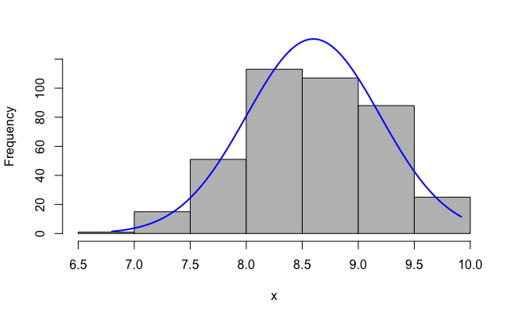

```r
plotNormalHistogram(graduate_admissions$CGPA)
```

Looks normal, but could be more normal with a transformation.

#### S**quare transformation**

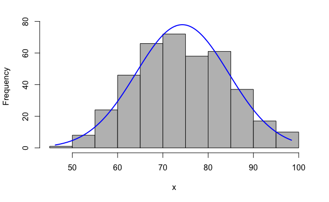

```r
graduate_admissions$CGPASQ <- graduate_admissions$CGPA * graduate_admissions$CGPA

  # Plot after transformation
    plotNormalHistogram(graduate_admissions$CGPASQ)
```

### **Meets assumption: Normality**

Meets the assumption of normality (after transformation).